HGG-oncohistones project [[source](https://github.com/fungenomics/HGG-oncohistones/blob/master/code/02-bulk_comparisons.Rmd)]

# 02 - Bulk RNAseq/ChIPseq comparisons

Selin Jessa []

18 October, 2022

# 1 Configuration

Configuration of project directory & analysis outputs:

**Show full config**

```r
source(here("rr_helpers.R"))

# Set up outputs
message("Document index: ", doc_id)
```

```
## Document index: 02
```

```r
# Specify where to save outputs
out        <- here("output", doc_id); dir.create(out, recursive = TRUE)
figout     <- here("figures", doc_id); dir.create(figout, recursive = TRUE)
cache      <- paste0(readLines(here("include/project_root.txt")), basename(here()), "/", doc_id, "/")
```

Outputs and figures will be saved at these paths, relative to project root:

```
## public/output/02
```

```
## public/figures/02
```

Setting a random seed:

```r
set.seed(100)
```

# 2 Overview

Here we interrogate differences in bulk RNAseq as well as H3K27ac and H3K27me3 ChIPseq data between tumor types (H3.1 vs H3.3K27M pontine gliomas, and pontine vs thalamic H3.3K27M gliomas). This document generates the scatter plots integrating H3K27ac/H3K27me3/RNAseq, as shown in Figures 2 and 4.

# 3 Libraries

```r
# Load libraries here
library(dplyr)
library(tidyr)
library(readr)
library(readxl)
library(glue)
library(tibble)
library(ggplot2)
library(ggrepel)
library(stringr)
library(purrr)
library(cowplot)
library(feather)
library(icytobox)

source(here("include/style.R")) # contains palettes & plotting utils
source(here("code/functions/RNAseq.R"))
ggplot2::theme_set(theme_min())
```

# 4 Load metadata

Load the sample metadata for the project:

```r
meta      <- read_tsv(here("data/metadata/metadata_patient_samples_NGS.tsv"))
```

```r
meta_chip <- read_tsv(here("data/metadata/metadata_chip_all.tsv")) %>%
    right_join(meta, by = c("BioID", "ID_paper", "Material")) %>%
    mutate(Factor = gsub("-M", "", Factor)) %>%
    filter(grepl("Cell-of-origin", Analyses))
```

# 5 Differential expression (pons vs. thalamus, and H3.1 vs H3.3)

Load the differential expression analyses between H3.1 vs H3.3 and pons vs. thalamic tumors:

```r
# H3.1 has log2FoldChange > 0
info_h31_vs_H33 <- read_tsv(here("data/RNAseq/pipeline_l3/DGE/HGG-H3.1.2K27M-Pons_vs_HGG-H3.3K27M-Pons/info.samples.tsv"))
dge_h31_vs_h33 <- read_tsv(here("data/RNAseq/pipeline_l3/DGE/HGG-H3.1.2K27M-Pons_vs_HGG-H3.3K27M-Pons/diff/Ensembl.ensGene.exon/HGG-H3.3K27M-PonsvsHGG-H3.1.2K27M-Pons.tsv")) %>%
    separate(ID, into = c("ENSID", "symbol"), sep = ":")

# double check no. of samples in each category
table(info_h31_vs_H33$Group)
```

```
##
## HGG-H3.1.2K27M-Pons   HGG-H3.3K27M-Pons
##                   9                  11
```

```r
# Thalamus has log2FoldChange > 0
info_thalamus_vs_pons <- read_tsv(here("data/RNAseq/pipeline_l3/DGE/HGG-H3.3K27M-Thal._vs_HGG-H3.3K27M-Pons/info.samples.tsv"))
dge_thalamus_vs_pons <- read_tsv(here("data/RNAseq/pipeline_l3/DGE/HGG-H3.3K27M-Thal._vs_HGG-H3.3K27M-Pons/diff/Ensembl.ensGene.exon/HGG-H3.3K27M-PonsvsHGG-H3.3K27M-Thal..tsv")) %>%
    separate(ID, into = c("ENSID", "symbol"), sep = ":")

# double check no. of samples in each category
table(info_thalamus_vs_pons$Group)
```

```
##
##  HGG-H3.3K27M-Pons HGG-H3.3K27M-Thal.
##                 11                  6
```

## 5.1 Prepare tables

We'll assemble 3 tables:

1. raw counts
2. DGE H3.1 vs H3.3
3. DGE thalamus vs pons

```r
# COUNTS -----------------------------------------------------------------------

# get sample order as Table 1
sample_order <- data.table::fread(here("data/metadata/bulk_info.samples.tsv"), data.table = FALSE) %>% .$Nickname

counts_RNA <- read.table(here("data/RNAseq/pipeline_l3/all/counts/Ensembl.ensGene.exon.raw.tsv.gz"),
                         header = T, sep = "\t", check.names = FALSE) %>%
    tibble::rownames_to_column(var = "ID") %>%
    separate(ID, into = c("ENSID", "symbol"), sep = ":") %>%
    arrange(ENSID) %>%
    .[, c("ENSID", "symbol", sample_order)] %T>%
    rr_write_tsv(glue("{out}/TABLE_bulk_counts.tsv"),
                 "Raw counts for bulk RNAseq data")
```

```
## ...writing description of TABLE_bulk_counts.tsv to public/output/02/TABLE_bulk_counts.desc
```

```r
# sanity checks
length(colnames(counts_RNA)) - 2
```

```
## [1] 64
```

```r
dim(counts_RNA)
```

```
## [1] 60234    66
```

```r
# DGE --------------------------------------------------------------------------
dge_h31_vs_h33 %>% arrange(ENSID) %>%
    rr_write_tsv(glue("{out}/TABLE_dge_H3.1_vs_H3.3.tsv"),
                 "Differential gene expression analysis for H3.1K27M pons vs H3.3K27M pons (LFC > 0 indicates up in H3.1K27M)")
```

```
## ...writing description of TABLE_dge_H3.1_vs_H3.3.tsv to public/output/02/TABLE_dge_H3.1_vs_H3.3.desc
```

```r
dge_thalamus_vs_pons %>% arrange(ENSID) %>%
    rr_write_tsv(glue("{out}/TABLE_dge_thal_vs_pons.tsv"),
                 "Differential gene expression analysis for H3.3K27M thalamic vs H3.3K27M pons (LFC > 0 indicates up in thalamic)")
```

```
## ...writing description of TABLE_dge_thal_vs_pons.tsv to public/output/02/TABLE_dge_thal_vs_pons.desc
```

```r
# sanity checks
dim(dge_h31_vs_h33)
```

```
## [1] 60234     8
```

```r
dim(dge_thalamus_vs_pons)
```

```
## [1] 60234     8
```

# 6 ChIPseq

## 6.1 Load data

```r
# slow
data_chip <- read_xlsx(here("data/ChIPseq/quantifications_@mhulswit/20210521_H3.3H3.3EZHIP_H3K27ac_H3K27me3_RefSeq_Promoters_SJ.xlsx"), skip = 1)
```

Let's separate out the data into the summary stats (group medians and z-scores) and per-sample quantifications, and convert to tidy (long) format. Starting with the per-sample quantifications:

```r
data_chip_tidy <- data_chip %>%
    dplyr::select(1:100, matches("Median_"),
                  # only keep relevant Z-scores
                  Z_H3.3K27M_Thalamus_H3.3K27M_Pons_H3K27ac,
                  Z_H3.3K27M_Pons_H3.1K27M_Pons_H3K27ac,
                  Z_H3.3K27M_Thalamus_H3.3K27M_Pons_H3K27me3,
                  Z_H3.3K27M_Pons_H3.1K27M_Pons_H3K27me3) %>%
    gather(dataset, value, 8:ncol(.)) %>%
    mutate(Mark = case_when(
        grepl("K27ac", dataset) ~ "H3K27ac",
        grepl("K27me3", dataset) ~ "H3K27me3"
    )) %>%
    mutate(Sample = gsub("_Count|_RPKM", "", dataset)) %>%
    left_join(meta_chip %>% mutate(bw = basename(Path_bw_internal)) %>% dplyr::select(ID_paper, bw, Replicate),
              # column name in ChIP quantification matches bigwig (bw) filename
              by = c("Sample" = "bw"))  %>%
    filter(!grepl("NormalPons", Sample)) %>%
    # only keep the relevant Z
    filter(!is.na(ID_paper) | grepl("^Median|^Z", Sample)) %>%
    # tidy
    mutate(Sample = case_when(
        grepl("Median_PFA_PF", Sample) ~ gsub("PFA_PF", "EZHIP_PFA", Sample),
        grepl("Median_H3.1K27M_PF", Sample) ~ gsub("PF", "PFA", Sample),
        TRUE ~ Sample))

# sanity check: ensure that no samples present in this dataset are *NOT* included
# in the ChIPseq metadata file
base::setdiff(unique(data_chip_tidy$ID_paper), unique(meta_chip$ID_paper))
```

```
## [1] NA
```

```r
save(data_chip_tidy, file = glue("{out}/data_chip_tidy.Rda"))

# make table
data_chip_tidy %>%
    mutate(ID_paper = case_when(
        grepl("^Z|^Median", Sample) ~ Sample,
        TRUE ~ paste0(ID_paper, "-", Replicate, "__", Mark)
    )) %>%
    dplyr::select(ID, gene_symbol = name, chr, start, end, strand, ID_paper, value) %>%
    pivot_wider(names_from = ID_paper, values_from = value) %>%
    arrange(chr, start) %>%
    rr_write_tsv(glue("{out}/TABLE_promoter_H3K27ac_H3K27me3_per_sample.tsv"),
                 "Promoter H3K27ac and H3K27me3 enrichment (RPKM) in each sample, and summary stats")
```

```
## ...writing description of TABLE_promoter_H3K27ac_H3K27me3_per_sample.tsv to public/output/02/TABLE_promoter_H3K27ac_H3K27me3_per_sample.desc
```

Tidy summary stats:

```r
data_chip_stats <- data_chip_tidy %>%
    filter(grepl("Z_", Sample)) %>%
    rename(statistic = Sample) %>%
    select(-ID_paper, -Replicate, -Mark, -dataset) %>%
    group_by(chr, strand, name, statistic) %>%
    top_n(1, `Exon Length`) %>%
    ungroup() %>%
    pivot_wider(names_from = statistic, values_from = value)

save(data_chip_stats, file = glue("{out}/data_chip_stats.Rda"))
```

Count samples:

```r
data_chip_tidy %>%
    left_join(meta %>% distinct(ID_paper, Group), by = "ID_paper") %>%
    distinct(ID_paper, Group, Mark) %>%
    group_by(Group, Mark) %>%
    count() %>%
    filter(Group %in% c("HGG-H3.1/2K27M-Pons",
                        "HGG-H3.3K27M-Pons",
                        "HGG-H3.3K27M-Thal."))
```

| Group | Mark | n |
| --- | --- | --- |
| HGG-H3.1/2K27M-Pons | H3K27ac | 14 |
| HGG-H3.1/2K27M-Pons | H3K27me3 | 3 |
| HGG-H3.3K27M-Pons | H3K27ac | 16 |
| HGG-H3.3K27M-Pons | H3K27me3 | 6 |
| HGG-H3.3K27M-Thal. | H3K27ac | 5 |
| HGG-H3.3K27M-Thal. | H3K27me3 | 4 |

## 6.2 Scatterplot for H3.1 vs H3.3 pons

Here, we'll combine the DGE data with each of different source of ChIP-seq analysis, following code used to do a similar analysis for H3.3G34 gliomas here: https://github.com/fungenomics/G34-gliomas/blob/master/bulk_transcriptome_epigenome/analysis/03-ChIPseq.Rmd#L151 (from Chen et al, 2020).

The input for the scatter plot is essentially a data frame where, for each gene, we have:

- A score for differential expression (e.g. log2FoldChange from DESeq2 differential expression analysis)
- A score for differential H3K27me3 (e.g. Z-score for promoter H3K27me3)
- A score for differential H3K27ac (e.g. Z-score for promoter H3K27ac)

```r
dge_h31_vs_h33_and_chip <- data_chip_stats %>%
    select(name, H3K27ac = Z_H3.3K27M_Pons_H3.1K27M_Pons_H3K27ac, H3K27me3 = Z_H3.3K27M_Pons_H3.1K27M_Pons_H3K27me3) %>%
    distinct() %>%
    mutate(H3K27ac = -as.numeric(H3K27ac),
           H3K27me3 = -as.numeric(H3K27me3)) %>%
    left_join(dge_h31_vs_h33, by = c("name" = "symbol")) %>%
    filter(baseMean > 100) %>%
    # remove mitochondrial and Y-RNA
    filter(!grepl("Y_RNA|^MT_", name))

dim(dge_h31_vs_h33_and_chip)
```

```
## [1] 14954    10
```

```r
# get limits of z-scores for x/y axes
xlim <- range(dge_h31_vs_h33_and_chip$H3K27ac)
ylim <- range(dge_h31_vs_h33_and_chip$H3K27me3)

# all genes
to_label <- dge_h31_vs_h33_and_chip %>%
    filter((H3K27ac > 1 | H3K27ac < -0.5) |
               (H3K27me3 > 2.5 | H3K27me3 < -3))
nrow(to_label)
```

```
## [1] 241
```

```
## ...writing source data of ggplot to public/figures/02/scatterplot_h31_vs_h33-1.source_data.tsv
```

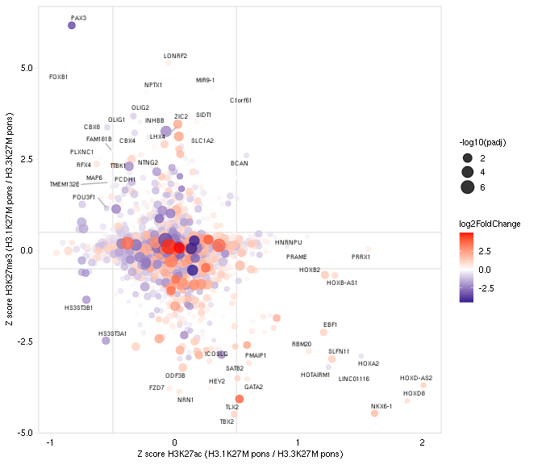

```r
dge_h31_vs_h33_and_chip %>%
    arrange(abs(log2FoldChange)) %>%
    mutate(name = factor(name, levels = unique(.$name))) %>%
    rr_ggplot(aes(x = H3K27ac, y = H3K27me3), plot_num = 1) +
    geom_hline(yintercept = c(-0.5, 0.5), size = 0.5, colour = "gray90") +
    geom_vline(xintercept = c(-0.5, 0.5), size = 0.5, colour = "gray90") +
    geom_point(aes(colour = log2FoldChange, size = -log10(padj)), alpha = 0.8) +
    scale_colour_gradient2(low = "navy", mid = "white", high = "red", midpoint = 0)  +
    geom_text_repel(aes(label = name), to_label,
                    inherit.aes = TRUE, size = 2, segment.color = "gray70") +
    xlab("Z score H3K27ac (H3.1K27M pons / H3.3K27M pons)") +
    ylab("Z score H3K27me3 (H3.1K27M pons / H3.3K27M pons)")
```

<sub>[figure @ *public/figures/02/scatterplot_h31_vs_h33...*]</sub>

## 6.3 Scatterplot for H3.3 pons vs H3.3 thalamus

This is a similar analysis to the one performed in the previous section.

```r
dge_pons_vs_thal_and_chip <- data_chip_stats %>%
    select(name,
           H3K27ac = Z_H3.3K27M_Thalamus_H3.3K27M_Pons_H3K27ac,
           H3K27me3 = Z_H3.3K27M_Thalamus_H3.3K27M_Pons_H3K27me3) %>%
    distinct() %>%
    mutate(H3K27ac = as.numeric(H3K27ac),
           H3K27me3 = as.numeric(H3K27me3)) %>%
    left_join(dge_thalamus_vs_pons, by = c("name" = "symbol")) %>%
    filter(baseMean > 100) %>%
    # remove mitochondrial and Y-RNA
    filter(!grepl("Y_RNA|^MT_", name))

dim(dge_pons_vs_thal_and_chip)
```

```
## [1] 14809    10
```

```r
# get limits of z-scores for x/y axes
xlim <- range(dge_pons_vs_thal_and_chip$H3K27ac)
ylim <- range(dge_pons_vs_thal_and_chip$H3K27me3)

to_label <- dge_pons_vs_thal_and_chip %>%
    filter((H3K27ac > 0.5 | H3K27ac < -0.2) &
               (H3K27me3 > 1 | H3K27me3 < -0.5) & abs(log2FoldChange) > 2) %>%
    filter(-log10(padj) > 4 | log2FoldChange > 0)
nrow(to_label)
```

```
## [1] 19
```

```
## ...writing source data of ggplot to public/figures/02/scatterplot_thal_vs_pons-1.source_data.tsv
```

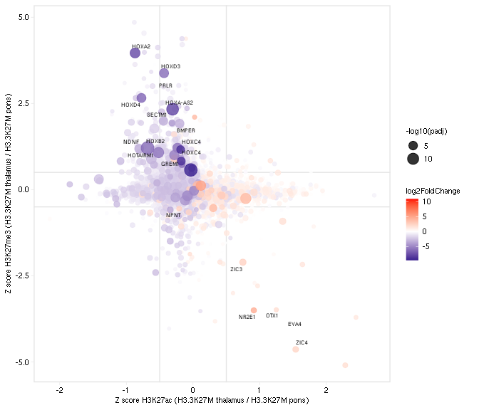

```r
dge_pons_vs_thal_and_chip %>%
    arrange(abs(log2FoldChange)) %>%
    mutate(name = factor(name, levels = unique(.$name))) %>%
    rr_ggplot(aes(x = H3K27ac, y = H3K27me3), plot_num = 1) +
    geom_hline(yintercept = c(-0.5, 0.5), size = 0.5, colour = "gray90") +
    geom_vline(xintercept = c(-0.5, 0.5), size = 0.5, colour = "gray90") +
    geom_point(aes(colour = log2FoldChange, size = -log10(padj)), alpha = 0.8) +
    scale_colour_gradient2(low = "navy", mid = "white", high = "red", midpoint = 0)  +
    geom_text_repel(aes(label = name), to_label,
                    inherit.aes = TRUE, size = 2, segment.color = "gray70") +
    xlab("Z score H3K27ac (H3.3K27M thalamus / H3.3K27M pons)") +
    ylab("Z score H3K27me3 (H3.3K27M thalamus / H3.3K27M pons)")
```

<sub>[figure @ *public/figures/02/scatterplot_thal_vs_pons...*]</sub>

# 7 Reproducibility

This document was last rendered on:

```
## 2022-10-18 14:17:13
```

The git repository and last commit:

```
## Local:    master /lustre06/project/6004736/sjessa/from_narval/HGG-oncohistones/public
## Remote:   master @ origin (git@github.com:fungenomics/HGG-oncohistones.git)
## Head:     [8082a4d] 2022-10-18: Merge branch 'master' of github.com:fungenomics/HGG-oncohistones
```

The random seed was set with `set.seed(100)`

The R session info:

```
## Error in get(genname, envir = envir) : object 'testthat_print' not found
```

The resources requested when this document was last rendered:

```
## #SBATCH --time=01:00:00
## #SBATCH --cpus-per-task=1
## #SBATCH --mem=20G
```

A project of the Kleinman Lab at McGill University, using the [rr](https://github.com/sjessa/rr/) reproducible research template.